# Part B

Jeremy Sapienza & Stefano D’Arrigo

22/11/2020

# **SDS HOMEWORK**

### **PART B**

**People have the power (. . . law. . . )**

$~$

First, we import the libraries that we will use for dealing with graphs (**igraph**), with the Bernoulli distribution (**Rlab**) and with the zeta distribution (**VGAM**).

Let $\mathbb{G}$ be the directed graph of vertices $V_{\mathbb{G}}=\{1, 2, 3, 4\}$ and edges $E_{\mathbb{G}}=\{(1, 2), (2, 3), (3, 4), (4, 1)\}$, as shown below:

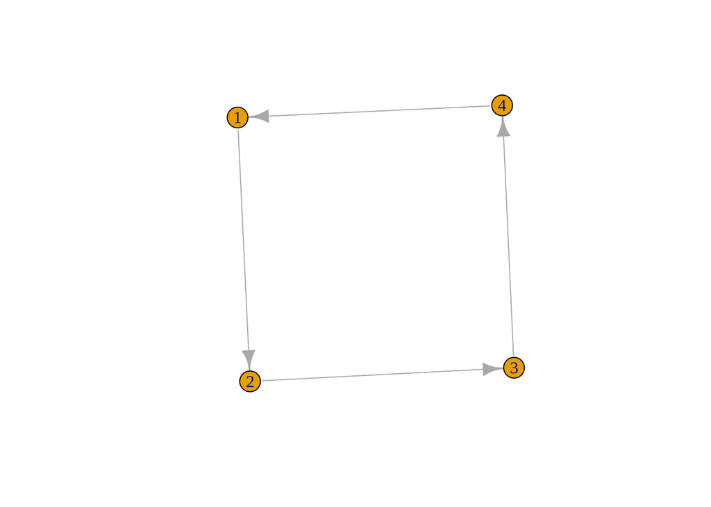

Each node of the graph $\mathbb{G}$ represents a page of the $\texttt{WWW}$. From this graph, we have to simulate the preferential attachment process, i.e. the process of growth of the network from the simple graph defined above to a one million pages (nodes) network. During each step of this process, a new node is attached to a vertex of $\mathbb{G}$, based on a certain event $E$.

In particular, the choice of the vertex to which link the new node is binded to a random variable $X\sim Ber(\gamma)$; since $\gamma = 0.5$, the target event is the tossing of a fair coin. If $X = 1$, a vertex is uniformly picked from $V_\mathbb{G}$. Otherwise, an existing link is uniformly picked from the set $E$; the destination node of the new link is the same of the selected link. To be clearer, this case can be compared to a lottery extraction: each node has a certain number of tickets (in-links). As in the previous case, the choice of the ticket is done uniformly at random, but now the node that holds a greater number of tickets, i.e. in-links, is more likely to be selected.

The following $\texttt{R}$ function implements the preferential attachment process:

```r
createLinks <- function(n.vertices, edges, gamma = 0.5) {
  vertices <- c(1:n.vertices) # create the vector of vertices. At the end, we know that the vertices will be n.vertices
  for(i in 5:n.vertices) { # start from 5 because the graph has already 4 nodes
    randBern <- rbern(1, gamma) # flip the coin
    dest.v <- NULL
    if(randBern == 1)
      dest.v <- sample(vertices[1:(i-1)], size = 1) # uniform sampling between the existing vertices at the ith iteration
    else
      dest.v <- sample(edges[,2], size = 1) # uniform sampling between the existing edges
    edges <- rbind(edges, c(i, dest.v)) # add the new edge
  }
  return(edges)
}
```

$~$

To speed up the computation of the network, we decided not to use the built-in methods available in **igraph** and to leverage the operations with vector and matrices. Nevertheless, **igraph** methods are used to visualize the graphs and highlight their properties. We provide another version of the function above in which we use **igraph**:

```r
createGraph <- function(G, n.vertices, gamma = 0.5){
  vertices.names <- as_ids(V(G))
  for(i in 5:n.vertices){
    randBern <- rbern(1, gamma) # 1: a link is to a page chosen uniformly at random - 0: copied from existing links.
    dest.vertex <- NULL
    if(randBern == 1){
      dest.vertex <- sample(vertices.names, size=1) #choose uniformly at random our page
    } else {
      edge.list <- get.edgelist(G)
      dest.vertex <- sample(edge.list[,2], size=1) #choose uniformly at random our page
    }
    G <- add_vertices(G, 1) %>%                    #add the link between the new page and the destination vertex
        add_edges(c(i, dest.vertex))
    vertices.names <- append(vertices.names, i)
  }

  return(G)

}
```

To easily see the output of the function `createLinks`, we test it with a small number of vertices, say 20, starting from the simple graph defined above:

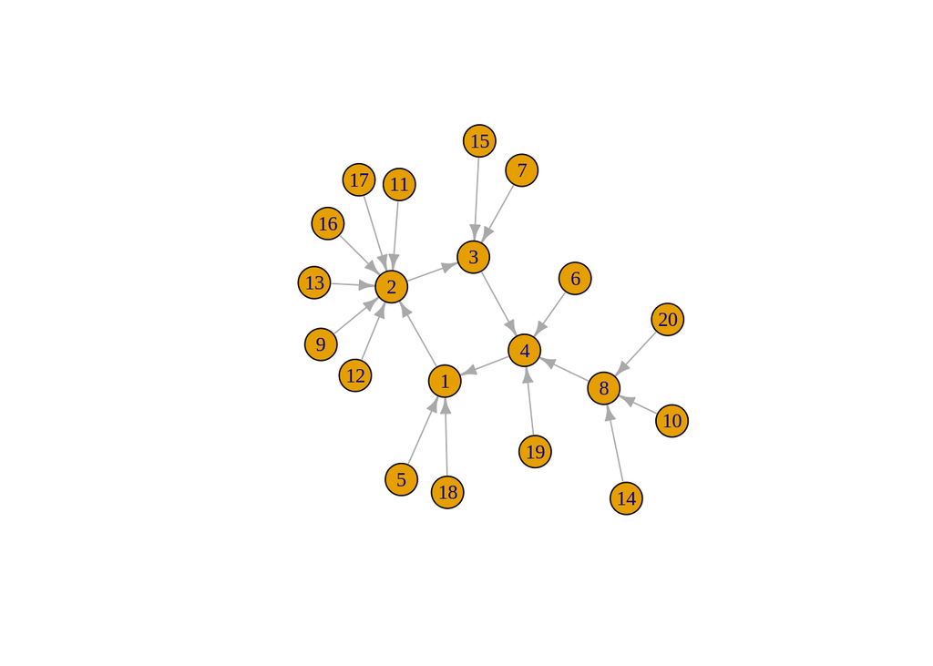

```r
n.v <- 20 # number of vertices
new.edges <- createLinks(n.vertices = n.v, edges, gamma = 0.5) # edge list of the new network
new.G <- graph_from_edgelist(new.edges) # create an igraph object
plot(new.G, vertex.size=18, layout= layout.kamada.kawai, edge.curverd=.2, arrow.size=.3, arrow.width=.2, edge.arrow.size=.6, vertex.label.cex=.9)
```

For each node of the graph, the number of incident links, that is the in-degree, is given by the built-in function `tabulate`, which counts the occurrences of a number in a vector:

```r
indegree.count.vertices <- tabulate(new.edges[,2], nbins = n.v) # count the in-degree of each node
```

At this point, it is worth to count the number of vertices for each in-degree value. The function `indegree.distribution` returns a vector of such counts:

```r
# count the vertices with k degree
indegree.distribution <- function(vertices.indegree){

  n = length(vertices.indegree)
  counts.d <- rep(0, n) # vector of degree counts

  for (i in 1:n)
    counts.d[vertices.indegree[i]+1] <- counts.d[vertices.indegree[i]+1] + 1

  return(counts.d)

}


counts.indegree <- indegree.distribution(vertices.indegree = indegree.count.vertices)
```

Now we are able to compute the empirical degree distribution by dividing each in-degree count by the number of vertices in the graph. This way, we obtain the empirical probability distribution of the degrees, according to the classical definition of probability:

$\mathbb{P}(E_i)=\frac{n_{E_i}}{n}$, where $E_i=\{\text{vertices of degree }i\},\text{ } n=|V|$

$~$

```r
normalized.indegree <- counts.indegree / n.v
normalized.indegree
```

```
##  [1] 0,75 0,00 0,00 0,15 0,05 0,00 0,00 0,05 0,00 0,00 0,00 0,00 0,00 0,00
## [15] 0,00 0,00 0,00 0,00 0,00 0,00
```

$~$

Before plotting the PMF of the empirical distribution, it is useful to recall the *discrete power law* and the *Poisson distribution*, with which we want to compare the in-degree distribution. Indeed, the goal we want to achieve is prove that the $\texttt{WWW}$ network follows a discrete power law distribution, instead of a Poisson distribution as random networks do.

$~$

The discrete power law distribution is such that:

$p \sim k^{- \alpha}$, where $k$ is the degree of the nodes.

$~$

We leverage the function `dzeta` available in the package **VGAM**.

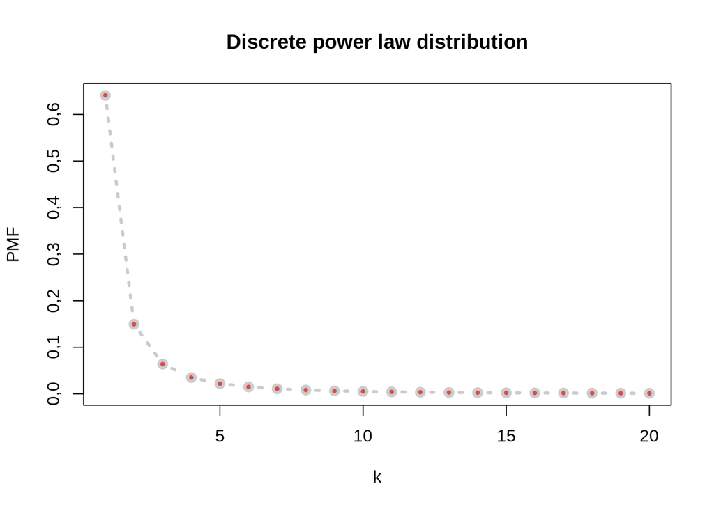

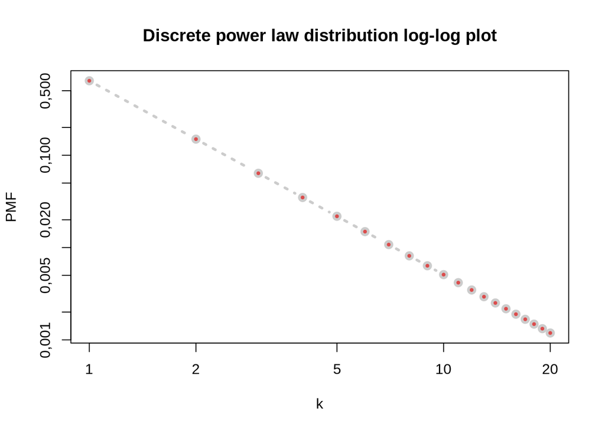

The Poisson distribution is such that:

$p_k = \frac{\mu^ke^{-\mu}}{k!}.$

$~$

We use the built-in function `dpois()` in order to get the Poisson distribution.

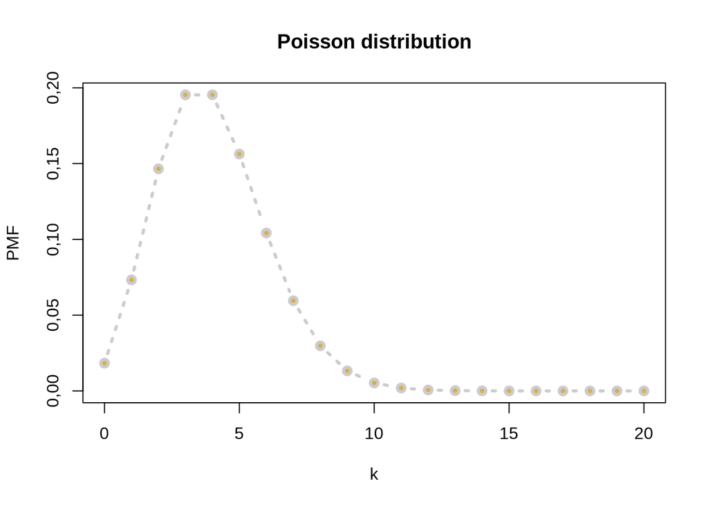

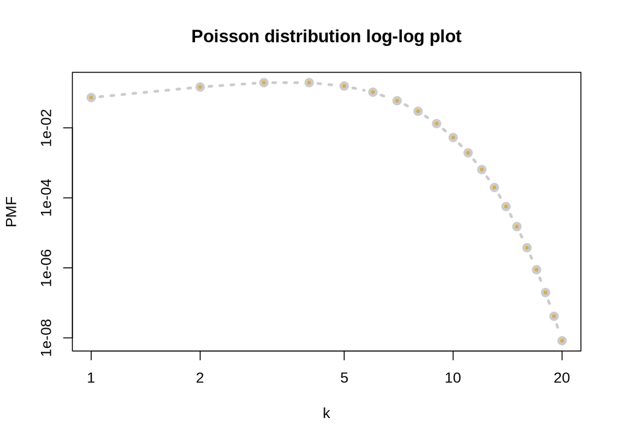

$~$

Finally, we plot the PMF of the empirical distribution in a log-log plot, comparing it with the two distributions mentioned above. Note that, to avoid errors in plotting the in-degree distribution, we translate it by taking into account $in.degree+1$:

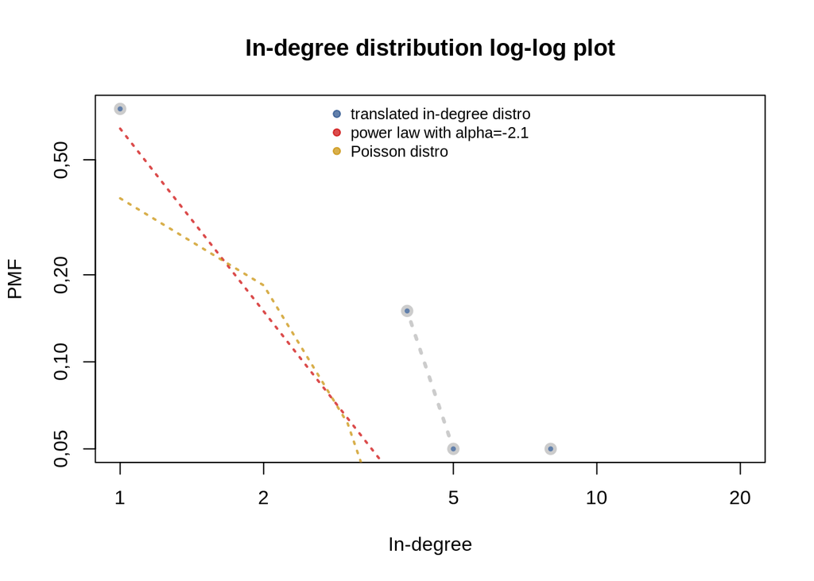

```r
#Plot the Log-Log plot
plot.PMF <- function(data) {
  colo <- c(rgb (32 / 255,74 / 255,135 / 255,0.7),
            rgb (204 / 255,0,0,0.7),
            rgb (200 / 255,141 / 255,0,0.7))
  n <- length(data)
  plot(1:n, data,
     main = "In-degree distribution log-log plot", xlab="In-degree", ylab="PMF",
     lty=3, lwd = 3, type = "b", pch = 21, col=gray(.8), bg = colo[1], log = "xy")
  lines(1:(n), dzeta(1:(n), 1.1), type = "l", lty = 3, lwd = 2, col = colo[2], pch = 21,
        bg = colo[2])
  lines(1:n, dpois(1:n, 1), type = "l", lty = 3, lwd = 2, col = colo[3], pch = 21,
        bg = colo[3])
  legend("top", c("translated in-degree distro", "power law with alpha=-2.1", "Poisson distro"),
         col = colo, pch = 19, bty = "n", cex = .8)
}

plot.PMF(normalized.indegree)
```

$~$

We plot also the complimentary cumulative degree distribution:

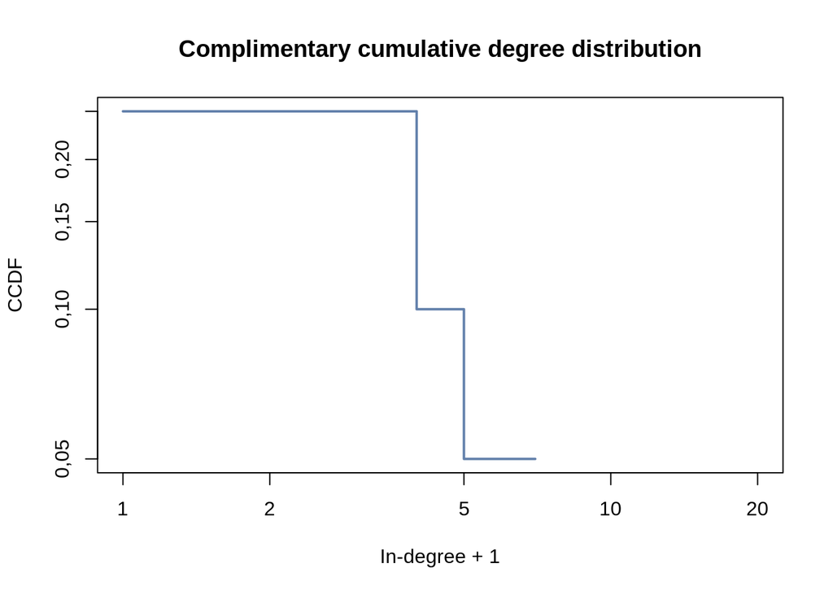

```r
# Plot the CCDF of X
plot.CCDF <- function(data) {
  colo <- c(rgb (32 / 255,74 / 255,135 / 255,0.7),
            rgb (204 / 255,0,0,0.7),
            rgb (200 / 255,141 / 255,0,0.7))
  n <- length(data)
  plot(1:n, 1-cumsum(data), type="s", log="xy",
     main = "Complimentary cumulative degree distribution", xlab="In-degree + 1", ylab="CCDF",
     lty=1, lwd=2, pch = 21, col = colo[1])
}

plot.CCDF(normalized.indegree)
```

$~$

Clearly, a graph of only 20 nodes is too small to let us analyze and understand the properties of a network like the $\texttt{WWW}$. Indeed, the PMF and the CCDF plots we obtained are not meaningful.

Hence, we now consider a network of 1 million of nodes and we simulate it for $M$ times. Since $M$ can be a small number, let $M=5$. With a `for` loop, we get $M$ empirical degree distributions.

```r
#input to get the M simulations
M <- 5
n.v <- 10^6
#define total indegree
total.indegree <- rep(0, n.v)

#simulate and get the indegree distribution mean
for(i in 1:M){
  new.edges <- createLinks(n.vertices = n.v, edges)

  indegree.count.vertex <- tabulate(new.edges[,2], nbins = n.v) # find the distribution

  total.indegree <- total.indegree + indegree.distribution(indegree.count.vertex)

}
```

$~$

Then, we take the mean of those distributions and we plot the PMF and the CCDF as before:

```r
normalized.indegree <- total.indegree / (length(total.indegree) * M)
normalized.indegree[1:20]
```

```
##  [1] 0,6666172 0,1666832 0,0667206 0,0334054 0,0190624 0,0118916 0,0079414
##  [8] 0,0055360 0,0040184 0,0030410 0,0023182 0,0018116 0,0014620 0,0011848
## [15] 0,0009636 0,0008158 0,0006930 0,0005964 0,0004870 0,0004246
```

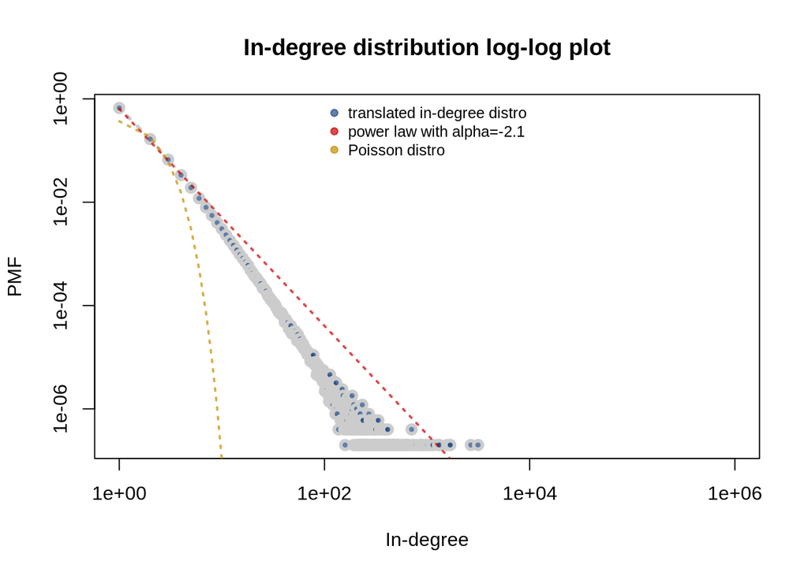

```r
plot.PMF(normalized.indegree)
```

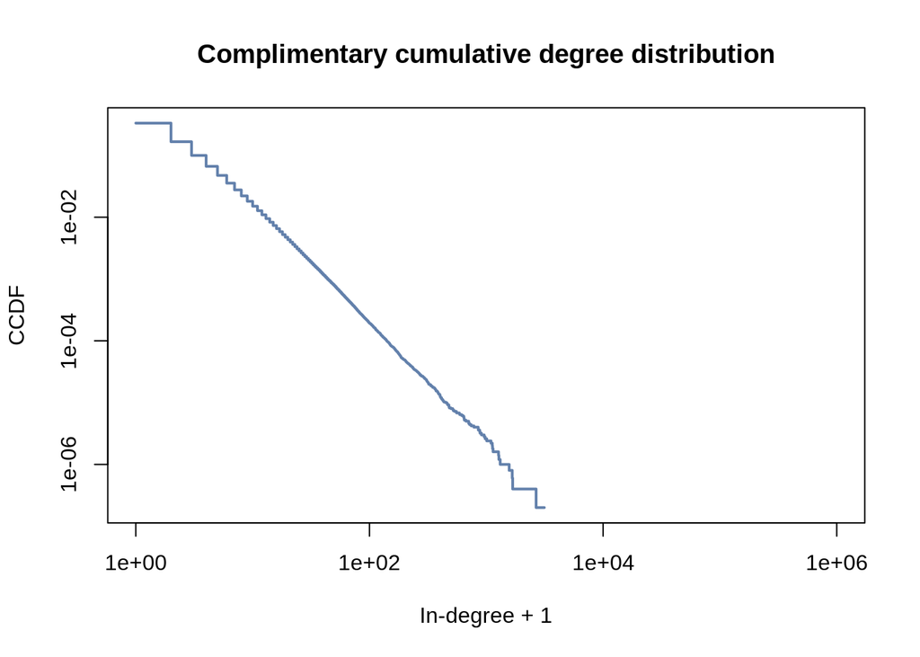

```r
plot.CCDF(normalized.indegree)
```

$~$

The results plotted show that the empirical degree distribution appoximately fits a discrete power law, since in a log-log plot the points appoximate a line.

$~$

Finally, we show a network of 500 nodes:

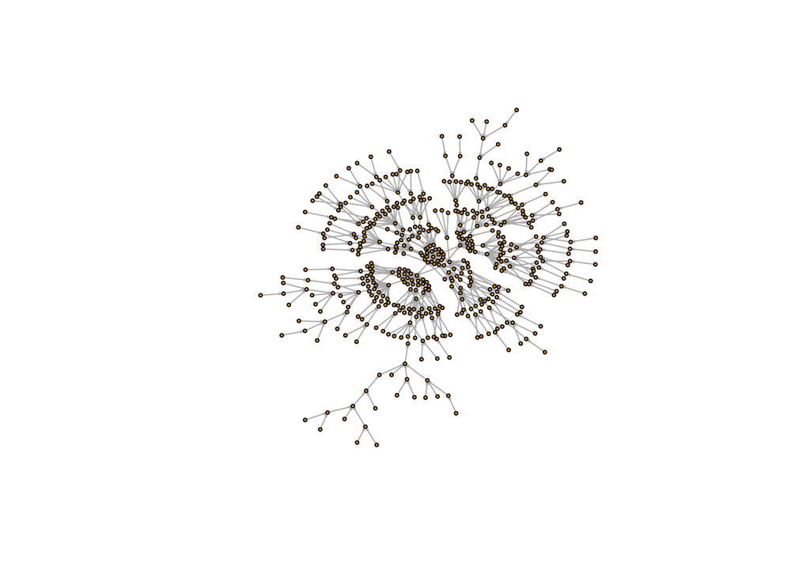

```r
new.edges2 <- createLinks(n.vertices = 500, edges)
new.G <- graph_from_edgelist(new.edges2)
plot(new.G, vertex.size=2, layout= layout.kamada.kawai, edge.curverd=.2, arrow.size=.1, arrow.width=.1, edge.arrow.size=.1, vertex.label=NA)
```